# Risk Factor Analysis

## Outcome Variable

**Outcome Variable:** haz

## Predictor Variables

**Intervention Variable:** hhwealth_quart

**Adjustment Set:**

- arm
- sex
- W_mage
- meducyrs
- feducyrs
- W_gagebrth
- W_birthwt
- W_birthlen
- W_nchldlt5
- W_parity
- delta_W_mage
- delta_meducyrs
- delta_feducyrs
- delta_W_gagebrth
- delta_W_birthwt
- delta_W_birthlen
- delta_W_nchldlt5
- delta_W_parity

## Stratifying Variables

The analysis was stratified on these variable(s):

- agecat
- studyid
- country

## Data Summary

| agecat | studyid | country | hhwealth_quart | n_cell | n |
| --- | --- | --- | --- | --- | --- |
| Birth | CMC-V-BCS-2002 | INDIA | Wealth Q4 | 32 | 92 |
| Birth | CMC-V-BCS-2002 | INDIA | Wealth Q1 | 15 | 92 |
| Birth | CMC-V-BCS-2002 | INDIA | Wealth Q2 | 20 | 92 |
| Birth | CMC-V-BCS-2002 | INDIA | Wealth Q3 | 25 | 92 |
| Birth | COHORTS | GUATEMALA | Wealth Q4 | 293 | 816 |
| Birth | COHORTS | GUATEMALA | Wealth Q1 | 157 | 816 |
| Birth | COHORTS | GUATEMALA | Wealth Q2 | 161 | 816 |
| Birth | COHORTS | GUATEMALA | Wealth Q3 | 205 | 816 |
| Birth | COHORTS | PHILIPPINES | Wealth Q4 | 842 | 3049 |
| Birth | COHORTS | PHILIPPINES | Wealth Q1 | 687 | 3049 |
| Birth | COHORTS | PHILIPPINES | Wealth Q2 | 538 | 3049 |
| Birth | COHORTS | PHILIPPINES | Wealth Q3 | 982 | 3049 |
| Birth | CONTENT | PERU | Wealth Q4 | 0 | 2 |
| Birth | CONTENT | PERU | Wealth Q1 | 0 | 2 |
| Birth | CONTENT | PERU | Wealth Q2 | 1 | 2 |
| Birth | CONTENT | PERU | Wealth Q3 | 1 | 2 |
| Birth | GMS-Nepal | NEPAL | Wealth Q4 | 173 | 696 |
| Birth | GMS-Nepal | NEPAL | Wealth Q1 | 175 | 696 |
| Birth | GMS-Nepal | NEPAL | Wealth Q2 | 174 | 696 |
| Birth | GMS-Nepal | NEPAL | Wealth Q3 | 174 | 696 |
| Birth | IRC | INDIA | Wealth Q4 | 91 | 388 |
| Birth | IRC | INDIA | Wealth Q1 | 98 | 388 |
| Birth | IRC | INDIA | Wealth Q2 | 99 | 388 |
| Birth | IRC | INDIA | Wealth Q3 | 100 | 388 |
| Birth | JiVitA-3 | BANGLADESH | Wealth Q4 | 5278 | 22434 |
| Birth | JiVitA-3 | BANGLADESH | Wealth Q1 | 5772 | 22434 |
| Birth | JiVitA-3 | BANGLADESH | Wealth Q2 | 5701 | 22434 |
| Birth | JiVitA-3 | BANGLADESH | Wealth Q3 | 5683 | 22434 |
| Birth | JiVitA-4 | BANGLADESH | Wealth Q4 | 654 | 2820 |
| Birth | JiVitA-4 | BANGLADESH | Wealth Q1 | 685 | 2820 |

[output cut: 178 more lines]

The following strata were considered:

- agecat: 24 months, studyid: CMC-V-BCS-2002, country: INDIA
- agecat: 24 months, studyid: COHORTS, country: GUATEMALA
- agecat: 24 months, studyid: COHORTS, country: PHILIPPINES
- agecat: 24 months, studyid: CONTENT, country: PERU
- agecat: 24 months, studyid: GMS-Nepal, country: NEPAL
- agecat: 24 months, studyid: IRC, country: INDIA
- agecat: 24 months, studyid: JiVitA-3, country: BANGLADESH
- agecat: 24 months, studyid: JiVitA-4, country: BANGLADESH
- agecat: 24 months, studyid: LCNI-5, country: MALAWI
- agecat: 24 months, studyid: MAL-ED, country: BANGLADESH
- agecat: 24 months, studyid: MAL-ED, country: BRAZIL
- agecat: 24 months, studyid: MAL-ED, country: INDIA
- agecat: 24 months, studyid: MAL-ED, country: NEPAL
- agecat: 24 months, studyid: MAL-ED, country: PERU
- agecat: 24 months, studyid: MAL-ED, country: SOUTH AFRICA
- agecat: 24 months, studyid: MAL-ED, country: TANZANIA, UNITED REPUBLIC OF
- agecat: 24 months, studyid: PROVIDE, country: BANGLADESH
- agecat: 24 months, studyid: TanzaniaChild2, country: TANZANIA, UNITED REPUBLIC OF
- agecat: 6 months, studyid: CMC-V-BCS-2002, country: INDIA
- agecat: 6 months, studyid: COHORTS, country: GUATEMALA
- agecat: 6 months, studyid: COHORTS, country: PHILIPPINES
- agecat: 6 months, studyid: CONTENT, country: PERU
- agecat: 6 months, studyid: GMS-Nepal, country: NEPAL
- agecat: 6 months, studyid: IRC, country: INDIA
- agecat: 6 months, studyid: JiVitA-3, country: BANGLADESH
- agecat: 6 months, studyid: JiVitA-4, country: BANGLADESH
- agecat: 6 months, studyid: LCNI-5, country: MALAWI
- agecat: 6 months, studyid: MAL-ED, country: BANGLADESH
- agecat: 6 months, studyid: MAL-ED, country: BRAZIL
- agecat: 6 months, studyid: MAL-ED, country: INDIA
- agecat: 6 months, studyid: MAL-ED, country: NEPAL
- agecat: 6 months, studyid: MAL-ED, country: PERU
- agecat: 6 months, studyid: MAL-ED, country: SOUTH AFRICA
- agecat: 6 months, studyid: MAL-ED, country: TANZANIA, UNITED REPUBLIC OF
- agecat: 6 months, studyid: PROVIDE, country: BANGLADESH
- agecat: 6 months, studyid: TanzaniaChild2, country: TANZANIA, UNITED REPUBLIC OF
- agecat: Birth, studyid: CMC-V-BCS-2002, country: INDIA
- agecat: Birth, studyid: COHORTS, country: GUATEMALA
- agecat: Birth, studyid: COHORTS, country: PHILIPPINES
- agecat: Birth, studyid: CONTENT, country: PERU
- agecat: Birth, studyid: GMS-Nepal, country: NEPAL
- agecat: Birth, studyid: IRC, country: INDIA
- agecat: Birth, studyid: JiVitA-3, country: BANGLADESH
- agecat: Birth, studyid: JiVitA-4, country: BANGLADESH
- agecat: Birth, studyid: MAL-ED, country: BANGLADESH
- agecat: Birth, studyid: MAL-ED, country: BRAZIL
- agecat: Birth, studyid: MAL-ED, country: INDIA
- agecat: Birth, studyid: MAL-ED, country: NEPAL
- agecat: Birth, studyid: MAL-ED, country: PERU
- agecat: Birth, studyid: MAL-ED, country: SOUTH AFRICA
- agecat: Birth, studyid: MAL-ED, country: TANZANIA, UNITED REPUBLIC OF
- agecat: Birth, studyid: PROVIDE, country: BANGLADESH

### Dropped Strata

Some strata were dropped due to rare outcomes:

- agecat: Birth, studyid: CONTENT, country: PERU
- agecat: Birth, studyid: MAL-ED, country: NEPAL
- agecat: 24 months, studyid: TanzaniaChild2, country: TANZANIA, UNITED REPUBLIC OF

## Methods Detail

We’re interested in the causal parameters $E[Y_a]$ for all values of $a \in \mathcal{A}$. These parameters represent the mean outcome if, possibly contrary to fact, we intervened to set all units to have $A=a$. Under the randomization and positivity assumptions, these are identified by the statistical parameters $\psi_a=E_W[E_{Y|A,W}(Y|A=a,W)]$. In addition, we’re interested in the mean of $Y$, $E[Y]$ under no intervention (the observed mean). We will estimate these parameters by using SuperLearner to fit the relevant likelihood factors – $E_{Y|A,W}(Y|A=a,W)$ and $p(A=a|W)$, and then updating our likelihood fit using a joint TMLE.

For unadjusted analyses ($W=\{\}$), initial likelihoods were estimated using Lrnr_glm to estimate the simple $E(Y|A)$ and Lrnr_mean to estimate $p(A)$. For adjusted analyses, a small library containing Lrnr_glmnet, Lrnr_xgboost, and Lrnr_mean was used.

Having estimated these parameters, we will then use the delta method to estimate relative risks and attributable risks relative to a prespecified baseline level of $A$.

# Results Detail

## Results Plots

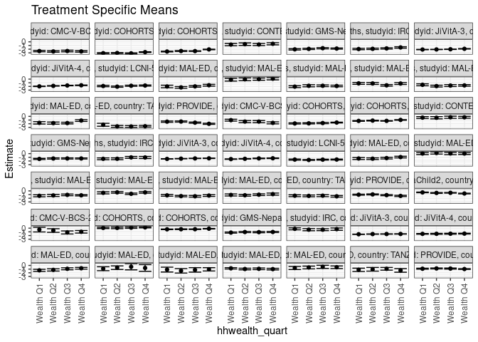

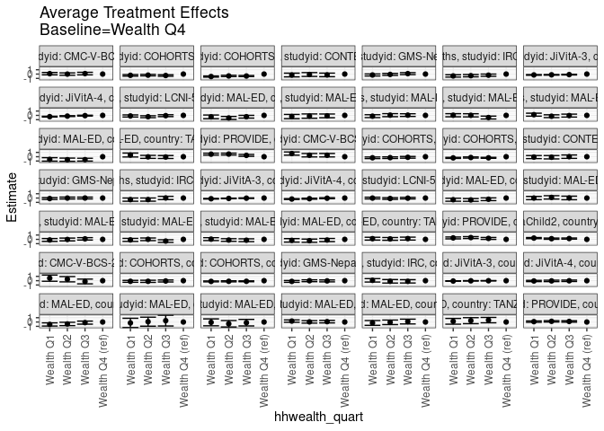

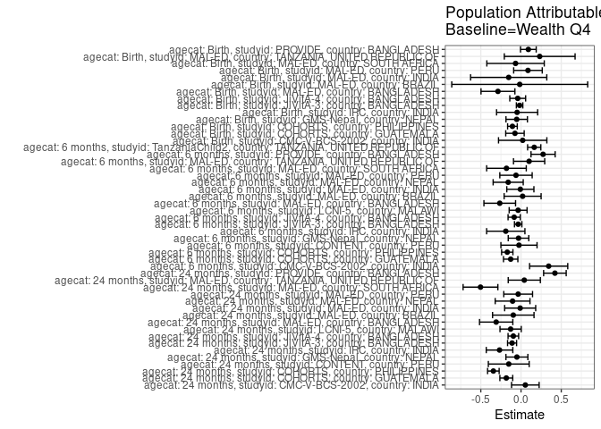

## Results Table

### Parameter: TSM

| agecat | studyid | country | intervention_level | baseline_level | estimate | ci_lower | ci_upper |
| --- | --- | --- | --- | --- | --- | --- | --- |
| Birth | CMC-V-BCS-2002 | INDIA | Wealth Q4 | NA | -0.9817992 | -1.3323827 | -0.6312158 |
| Birth | CMC-V-BCS-2002 | INDIA | Wealth Q1 | NA | -0.3950497 | -1.0292636 | 0.2391642 |
| Birth | CMC-V-BCS-2002 | INDIA | Wealth Q2 | NA | -0.6409380 | -1.1393372 | -0.1425388 |
| Birth | CMC-V-BCS-2002 | INDIA | Wealth Q3 | NA | -1.1631480 | -1.5758593 | -0.7504367 |
| Birth | COHORTS | GUATEMALA | Wealth Q4 | NA | 0.2207720 | 0.0801558 | 0.3613882 |
| Birth | COHORTS | GUATEMALA | Wealth Q1 | NA | 0.0755879 | -0.0950231 | 0.2461990 |
| Birth | COHORTS | GUATEMALA | Wealth Q2 | NA | 0.0772731 | -0.1292978 | 0.2838440 |
| Birth | COHORTS | GUATEMALA | Wealth Q3 | NA | 0.1518373 | -0.0307768 | 0.3344515 |
| Birth | COHORTS | PHILIPPINES | Wealth Q4 | NA | -0.1423735 | -0.2123269 | -0.0724200 |
| Birth | COHORTS | PHILIPPINES | Wealth Q1 | NA | -0.3110423 | -0.3954601 | -0.2266245 |
| Birth | COHORTS | PHILIPPINES | Wealth Q2 | NA | -0.2872390 | -0.3891379 | -0.1853401 |
| Birth | COHORTS | PHILIPPINES | Wealth Q3 | NA | -0.2827509 | -0.3524363 | -0.2130654 |
| Birth | GMS-Nepal | NEPAL | Wealth Q4 | NA | -1.0313882 | -1.1892963 | -0.8734801 |
| Birth | GMS-Nepal | NEPAL | Wealth Q1 | NA | -1.1973583 | -1.3410259 | -1.0536907 |
| Birth | GMS-Nepal | NEPAL | Wealth Q2 | NA | -1.0472445 | -1.2036979 | -0.8907911 |
| Birth | GMS-Nepal | NEPAL | Wealth Q3 | NA | -1.0779451 | -1.2374423 | -0.9184479 |
| Birth | IRC | INDIA | Wealth Q4 | NA | -0.2592279 | -0.5738767 | 0.0554209 |
| Birth | IRC | INDIA | Wealth Q1 | NA | -0.1784604 | -0.4542038 | 0.0972830 |
| Birth | IRC | INDIA | Wealth Q2 | NA | -0.4022026 | -0.6940198 | -0.1103855 |
| Birth | IRC | INDIA | Wealth Q3 | NA | -0.4101653 | -0.6652605 | -0.1550701 |
| Birth | JiVitA-3 | BANGLADESH | Wealth Q4 | NA | -1.5718308 | -1.6182183 | -1.5254432 |
| Birth | JiVitA-3 | BANGLADESH | Wealth Q1 | NA | -1.6528299 | -1.6881404 | -1.6175194 |
| Birth | JiVitA-3 | BANGLADESH | Wealth Q2 | NA | -1.6022785 | -1.6361347 | -1.5684224 |
| Birth | JiVitA-3 | BANGLADESH | Wealth Q3 | NA | -1.5869393 | -1.6203499 | -1.5535286 |
| Birth | JiVitA-4 | BANGLADESH | Wealth Q4 | NA | -1.4823989 | -1.5922339 | -1.3725639 |
| Birth | JiVitA-4 | BANGLADESH | Wealth Q1 | NA | -1.5500311 | -1.6449224 | -1.4551397 |
| Birth | JiVitA-4 | BANGLADESH | Wealth Q2 | NA | -1.5329834 | -1.6532307 | -1.4127361 |
| Birth | JiVitA-4 | BANGLADESH | Wealth Q3 | NA | -1.5091598 | -1.6296034 | -1.3887161 |
| Birth | MAL-ED | BANGLADESH | Wealth Q4 | NA | -0.7663769 | -0.9963325 | -0.5364213 |
| Birth | MAL-ED | BANGLADESH | Wealth Q1 | NA | -1.3312089 | -1.6199638 | -1.0424541 |

[output cut: 166 more lines]

### Parameter: E(Y)

| agecat | studyid | country | intervention_level | baseline_level | estimate | ci_lower | ci_upper |
| --- | --- | --- | --- | --- | --- | --- | --- |
| Birth | CMC-V-BCS-2002 | INDIA | NA | NA | -0.9611957 | -1.1776967 | -0.7446946 |
| Birth | COHORTS | GUATEMALA | NA | NA | 0.1452941 | 0.0610109 | 0.2295774 |
| Birth | COHORTS | PHILIPPINES | NA | NA | -0.2491505 | -0.2881717 | -0.2101294 |
| Birth | GMS-Nepal | NEPAL | NA | NA | -1.0851580 | -1.1651811 | -1.0051350 |
| Birth | IRC | INDIA | NA | NA | -0.3080412 | -0.4687931 | -0.1472894 |
| Birth | JiVitA-3 | BANGLADESH | NA | NA | -1.5897094 | -1.6089856 | -1.5704331 |
| Birth | JiVitA-4 | BANGLADESH | NA | NA | -1.5236135 | -1.5727559 | -1.4744711 |
| Birth | MAL-ED | BANGLADESH | NA | NA | -1.0530516 | -1.1896058 | -0.9164975 |
| Birth | MAL-ED | BRAZIL | NA | NA | -0.6963333 | -0.9881882 | -0.4044785 |
| Birth | MAL-ED | INDIA | NA | NA | -1.2070732 | -1.5254820 | -0.8886644 |
| Birth | MAL-ED | PERU | NA | NA | -0.9141395 | -1.0364098 | -0.7918693 |
| Birth | MAL-ED | SOUTH AFRICA | NA | NA | -0.5523958 | -0.7550074 | -0.3497843 |
| Birth | MAL-ED | TANZANIA, UNITED REPUBLIC OF | NA | NA | -1.1225000 | -1.3335666 | -0.9114334 |
| Birth | PROVIDE | BANGLADESH | NA | NA | -0.8851020 | -0.9601332 | -0.8100709 |
| 6 months | CMC-V-BCS-2002 | INDIA | NA | NA | -1.4234508 | -1.5645974 | -1.2823042 |
| 6 months | COHORTS | GUATEMALA | NA | NA | -1.8112324 | -1.8807284 | -1.7417365 |
| 6 months | COHORTS | PHILIPPINES | NA | NA | -1.1405724 | -1.1824954 | -1.0986493 |
| 6 months | CONTENT | PERU | NA | NA | -0.2785256 | -0.4098735 | -0.1471776 |
| 6 months | GMS-Nepal | NEPAL | NA | NA | -1.3508392 | -1.4290633 | -1.2726152 |
| 6 months | IRC | INDIA | NA | NA | -1.2344062 | -1.3658524 | -1.1029600 |
| 6 months | JiVitA-3 | BANGLADESH | NA | NA | -1.3132090 | -1.3363486 | -1.2900693 |
| 6 months | JiVitA-4 | BANGLADESH | NA | NA | -1.3440477 | -1.3813060 | -1.3067894 |
| 6 months | LCNI-5 | MALAWI | NA | NA | -1.6426961 | -1.7120603 | -1.5733318 |
| 6 months | MAL-ED | BANGLADESH | NA | NA | -1.2026806 | -1.3203025 | -1.0850586 |
| 6 months | MAL-ED | BRAZIL | NA | NA | 0.0475758 | -0.0963508 | 0.1915023 |
| 6 months | MAL-ED | INDIA | NA | NA | -1.2070638 | -1.3255909 | -1.0885368 |
| 6 months | MAL-ED | NEPAL | NA | NA | -0.5615819 | -0.6741832 | -0.4489807 |
| 6 months | MAL-ED | PERU | NA | NA | -1.3248549 | -1.4336721 | -1.2160378 |
| 6 months | MAL-ED | SOUTH AFRICA | NA | NA | -1.0547925 | -1.1843544 | -0.9252306 |
| 6 months | MAL-ED | TANZANIA, UNITED REPUBLIC OF | NA | NA | -1.3687449 | -1.4907629 | -1.2467270 |
| 6 months | PROVIDE | BANGLADESH | NA | NA | -1.0916915 | -1.1661176 | -1.0172654 |
| 6 months | TanzaniaChild2 | TANZANIA, UNITED REPUBLIC OF | NA | NA | -0.5442232 | -0.5932373 | -0.4952090 |
| 24 months | CMC-V-BCS-2002 | INDIA | NA | NA | -2.5588679 | -2.6583730 | -2.4593629 |
| 24 months | COHORTS | GUATEMALA | NA | NA | -2.9893430 | -3.0546993 | -2.9239867 |
| 24 months | COHORTS | PHILIPPINES | NA | NA | -2.4141145 | -2.4590818 | -2.3691473 |
| 24 months | CONTENT | PERU | NA | NA | -0.6868598 | -0.8388476 | -0.5348719 |
| 24 months | GMS-Nepal | NEPAL | NA | NA | -1.8874180 | -1.9728588 | -1.8019773 |
| 24 months | IRC | INDIA | NA | NA | -1.7987775 | -1.8923914 | -1.7051636 |
| 24 months | JiVitA-3 | BANGLADESH | NA | NA | -2.0135591 | -2.0412422 | -1.9858759 |
| 24 months | JiVitA-4 | BANGLADESH | NA | NA | -1.7803708 | -1.8158650 | -1.7448765 |
| 24 months | LCNI-5 | MALAWI | NA | NA | -1.8822648 | -1.9637218 | -1.8008078 |
| 24 months | MAL-ED | BANGLADESH | NA | NA | -1.9783962 | -2.1050210 | -1.8517715 |
| 24 months | MAL-ED | BRAZIL | NA | NA | 0.0061144 | -0.1625850 | 0.1748138 |
| 24 months | MAL-ED | INDIA | NA | NA | -1.8861894 | -2.0110006 | -1.7613783 |
| 24 months | MAL-ED | NEPAL | NA | NA | -1.3075877 | -1.4270718 | -1.1881037 |
| 24 months | MAL-ED | PERU | NA | NA | -1.7524710 | -1.8736426 | -1.6312994 |
| 24 months | MAL-ED | SOUTH AFRICA | NA | NA | -1.6450595 | -1.7797240 | -1.5103950 |
| 24 months | MAL-ED | TANZANIA, UNITED REPUBLIC OF | NA | NA | -2.6455607 | -2.7807256 | -2.5103959 |
| 24 months | PROVIDE | BANGLADESH | NA | NA | -1.6024221 | -1.6857420 | -1.5191023 |

### Parameter: ATE

| agecat | studyid | country | intervention_level | baseline_level | estimate | ci_lower | ci_upper |
| --- | --- | --- | --- | --- | --- | --- | --- |
| Birth | CMC-V-BCS-2002 | INDIA | Wealth Q4 | Wealth Q4 | 0.0000000 | 0.0000000 | 0.0000000 |
| Birth | CMC-V-BCS-2002 | INDIA | Wealth Q1 | Wealth Q4 | 0.5867495 | -0.1334117 | 1.3069107 |
| Birth | CMC-V-BCS-2002 | INDIA | Wealth Q2 | Wealth Q4 | 0.3408612 | -0.2687294 | 0.9504518 |
| Birth | CMC-V-BCS-2002 | INDIA | Wealth Q3 | Wealth Q4 | -0.1813488 | -0.7339001 | 0.3712026 |
| Birth | COHORTS | GUATEMALA | Wealth Q4 | Wealth Q4 | 0.0000000 | 0.0000000 | 0.0000000 |
| Birth | COHORTS | GUATEMALA | Wealth Q1 | Wealth Q4 | -0.1451841 | -0.3663943 | 0.0760260 |
| Birth | COHORTS | GUATEMALA | Wealth Q2 | Wealth Q4 | -0.1434990 | -0.3935035 | 0.1065056 |
| Birth | COHORTS | GUATEMALA | Wealth Q3 | Wealth Q4 | -0.0689347 | -0.2996048 | 0.1617353 |
| Birth | COHORTS | PHILIPPINES | Wealth Q4 | Wealth Q4 | 0.0000000 | 0.0000000 | 0.0000000 |
| Birth | COHORTS | PHILIPPINES | Wealth Q1 | Wealth Q4 | -0.1686688 | -0.2763738 | -0.0609638 |
| Birth | COHORTS | PHILIPPINES | Wealth Q2 | Wealth Q4 | -0.1448656 | -0.2665191 | -0.0232120 |
| Birth | COHORTS | PHILIPPINES | Wealth Q3 | Wealth Q4 | -0.1403774 | -0.2369103 | -0.0438445 |
| Birth | GMS-Nepal | NEPAL | Wealth Q4 | Wealth Q4 | 0.0000000 | 0.0000000 | 0.0000000 |
| Birth | GMS-Nepal | NEPAL | Wealth Q1 | Wealth Q4 | -0.1659701 | -0.3754707 | 0.0435306 |
| Birth | GMS-Nepal | NEPAL | Wealth Q2 | Wealth Q4 | -0.0158563 | -0.2331057 | 0.2013931 |
| Birth | GMS-Nepal | NEPAL | Wealth Q3 | Wealth Q4 | -0.0465569 | -0.2669566 | 0.1738429 |
| Birth | IRC | INDIA | Wealth Q4 | Wealth Q4 | 0.0000000 | 0.0000000 | 0.0000000 |
| Birth | IRC | INDIA | Wealth Q1 | Wealth Q4 | 0.0807675 | -0.3171535 | 0.4786886 |
| Birth | IRC | INDIA | Wealth Q2 | Wealth Q4 | -0.1429747 | -0.5502909 | 0.2643414 |
| Birth | IRC | INDIA | Wealth Q3 | Wealth Q4 | -0.1509374 | -0.5344478 | 0.2325731 |
| Birth | JiVitA-3 | BANGLADESH | Wealth Q4 | Wealth Q4 | 0.0000000 | 0.0000000 | 0.0000000 |
| Birth | JiVitA-3 | BANGLADESH | Wealth Q1 | Wealth Q4 | -0.0809991 | -0.1348362 | -0.0271621 |
| Birth | JiVitA-3 | BANGLADESH | Wealth Q2 | Wealth Q4 | -0.0304478 | -0.0824119 | 0.0215163 |
| Birth | JiVitA-3 | BANGLADESH | Wealth Q3 | Wealth Q4 | -0.0151085 | -0.0672721 | 0.0370551 |
| Birth | JiVitA-4 | BANGLADESH | Wealth Q4 | Wealth Q4 | 0.0000000 | 0.0000000 | 0.0000000 |
| Birth | JiVitA-4 | BANGLADESH | Wealth Q1 | Wealth Q4 | -0.0676322 | -0.2131331 | 0.0778687 |
| Birth | JiVitA-4 | BANGLADESH | Wealth Q2 | Wealth Q4 | -0.0505845 | -0.2140529 | 0.1128838 |
| Birth | JiVitA-4 | BANGLADESH | Wealth Q3 | Wealth Q4 | -0.0267609 | -0.1894410 | 0.1359192 |
| Birth | MAL-ED | BANGLADESH | Wealth Q4 | Wealth Q4 | 0.0000000 | 0.0000000 | 0.0000000 |
| Birth | MAL-ED | BANGLADESH | Wealth Q1 | Wealth Q4 | -0.5648321 | -0.9349429 | -0.1947213 |

[output cut: 166 more lines]

### Parameter: PAR

| agecat | studyid | country | intervention_level | baseline_level | estimate | ci_lower | ci_upper |
| --- | --- | --- | --- | --- | --- | --- | --- |
| Birth | CMC-V-BCS-2002 | INDIA | Wealth Q4 | NA | 0.0206036 | -0.2797274 | 0.3209345 |
| Birth | COHORTS | GUATEMALA | Wealth Q4 | NA | -0.0754779 | -0.1900909 | 0.0391350 |
| Birth | COHORTS | PHILIPPINES | Wealth Q4 | NA | -0.1067771 | -0.1667827 | -0.0467715 |
| Birth | GMS-Nepal | NEPAL | Wealth Q4 | NA | -0.0537698 | -0.1870466 | 0.0795069 |
| Birth | IRC | INDIA | Wealth Q4 | NA | -0.0488133 | -0.3040278 | 0.2064011 |
| Birth | JiVitA-3 | BANGLADESH | Wealth Q4 | NA | -0.0178786 | -0.0580143 | 0.0222571 |
| Birth | JiVitA-4 | BANGLADESH | Wealth Q4 | NA | -0.0412146 | -0.1395880 | 0.0571588 |
| Birth | MAL-ED | BANGLADESH | Wealth Q4 | NA | -0.2866748 | -0.4972605 | -0.0760890 |
| Birth | MAL-ED | BRAZIL | Wealth Q4 | NA | -0.0163190 | -0.8607800 | 0.8281420 |
| Birth | MAL-ED | INDIA | Wealth Q4 | NA | -0.1533232 | -0.6267868 | 0.3201405 |
| Birth | MAL-ED | PERU | Wealth Q4 | NA | 0.0862403 | -0.0912963 | 0.2637769 |
| Birth | MAL-ED | SOUTH AFRICA | Wealth Q4 | NA | -0.0681329 | -0.4249632 | 0.2886974 |
| Birth | MAL-ED | TANZANIA, UNITED REPUBLIC OF | Wealth Q4 | NA | 0.2321000 | -0.2076469 | 0.6718469 |
| Birth | PROVIDE | BANGLADESH | Wealth Q4 | NA | 0.0909764 | -0.0065080 | 0.1884608 |
| 6 months | CMC-V-BCS-2002 | INDIA | Wealth Q4 | NA | 0.3435243 | 0.1064152 | 0.5806335 |
| 6 months | COHORTS | GUATEMALA | Wealth Q4 | NA | -0.1286837 | -0.2179087 | -0.0394586 |
| 6 months | COHORTS | PHILIPPINES | Wealth Q4 | NA | -0.1710911 | -0.2413895 | -0.1007926 |
| 6 months | CONTENT | PERU | Wealth Q4 | NA | -0.0256553 | -0.2501851 | 0.1988745 |
| 6 months | GMS-Nepal | NEPAL | Wealth Q4 | NA | -0.0312000 | -0.1590767 | 0.0966767 |
| 6 months | IRC | INDIA | Wealth Q4 | NA | -0.1895150 | -0.4273954 | 0.0483654 |
| 6 months | JiVitA-3 | BANGLADESH | Wealth Q4 | NA | -0.0353798 | -0.0813923 | 0.0106327 |
| 6 months | JiVitA-4 | BANGLADESH | Wealth Q4 | NA | -0.0851491 | -0.1611555 | -0.0091428 |
| 6 months | LCNI-5 | MALAWI | Wealth Q4 | NA | -0.0363105 | -0.1475246 | 0.0749037 |
| 6 months | MAL-ED | BANGLADESH | Wealth Q4 | NA | -0.2645136 | -0.4612131 | -0.0678141 |
| 6 months | MAL-ED | BRAZIL | Wealth Q4 | NA | 0.0197578 | -0.2100144 | 0.2495300 |
| 6 months | MAL-ED | INDIA | Wealth Q4 | NA | -0.0084781 | -0.1770232 | 0.1600670 |
| 6 months | MAL-ED | NEPAL | Wealth Q4 | NA | -0.1596975 | -0.3467220 | 0.0273270 |
| 6 months | MAL-ED | PERU | Wealth Q4 | NA | -0.0626173 | -0.2636972 | 0.1384626 |
| 6 months | MAL-ED | SOUTH AFRICA | Wealth Q4 | NA | -0.1810636 | -0.4271708 | 0.0650436 |
| 6 months | MAL-ED | TANZANIA, UNITED REPUBLIC OF | Wealth Q4 | NA | 0.1003949 | -0.0935534 | 0.2943433 |
| 6 months | PROVIDE | BANGLADESH | Wealth Q4 | NA | 0.2741044 | 0.1241385 | 0.4240702 |
| 6 months | TanzaniaChild2 | TANZANIA, UNITED REPUBLIC OF | Wealth Q4 | NA | 0.1638491 | 0.0816811 | 0.2460171 |
| 24 months | CMC-V-BCS-2002 | INDIA | Wealth Q4 | NA | 0.0535519 | -0.1178831 | 0.2249869 |
| 24 months | COHORTS | GUATEMALA | Wealth Q4 | NA | -0.1830176 | -0.2628965 | -0.1031387 |
| 24 months | COHORTS | PHILIPPINES | Wealth Q4 | NA | -0.3437478 | -0.4155597 | -0.2719358 |
| 24 months | CONTENT | PERU | Wealth Q4 | NA | -0.1524954 | -0.4062438 | 0.1012530 |
| 24 months | GMS-Nepal | NEPAL | Wealth Q4 | NA | -0.0512876 | -0.1876228 | 0.0850476 |
| 24 months | IRC | INDIA | Wealth Q4 | NA | -0.2671563 | -0.4322347 | -0.1020779 |
| 24 months | JiVitA-3 | BANGLADESH | Wealth Q4 | NA | -0.1113079 | -0.1674374 | -0.0551785 |
| 24 months | JiVitA-4 | BANGLADESH | Wealth Q4 | NA | -0.0955805 | -0.1613241 | -0.0298368 |
| 24 months | LCNI-5 | MALAWI | Wealth Q4 | NA | -0.1293710 | -0.2614796 | 0.0027376 |
| 24 months | MAL-ED | BANGLADESH | Wealth Q4 | NA | -0.3088290 | -0.5156751 | -0.1019829 |
| 24 months | MAL-ED | BRAZIL | Wealth Q4 | NA | -0.0961992 | -0.3537482 | 0.1613498 |
| 24 months | MAL-ED | INDIA | Wealth Q4 | NA | -0.0106561 | -0.2034729 | 0.1821607 |
| 24 months | MAL-ED | NEPAL | Wealth Q4 | NA | -0.1049233 | -0.3209910 | 0.1111444 |
| 24 months | MAL-ED | PERU | Wealth Q4 | NA | -0.0355530 | -0.2143269 | 0.1432210 |
| 24 months | MAL-ED | SOUTH AFRICA | Wealth Q4 | NA | -0.5038097 | -0.7198261 | -0.2877933 |
| 24 months | MAL-ED | TANZANIA, UNITED REPUBLIC OF | Wealth Q4 | NA | 0.0405114 | -0.1592473 | 0.2402701 |
| 24 months | PROVIDE | BANGLADESH | Wealth Q4 | NA | 0.4210312 | 0.2807615 | 0.5613010 |